# Step 1.0: Cohort Check

Mia Charifson

December 26, 2023

## Cohort check and variables

Goals of this document: - Check all inclusion and exclusion criteria closely in cohort provided by Chuan - Check the burn-in period for encounters and whether they re-engage within a year from entry into cohort (LTFU at baseline) - Derive loss to follow-up during the follow-up period - Derive censoring due to menopause, death, receiving a hysterectomy or bilateral oophorectomy - Try to identify referral patients within the study population (referred directly into OBGYN in 2017)

```r
library(tidyverse)
library(ggplot2)
library(lubridate)
library(tableone)
library(arsenal)
library(readxl)
```

```r
pat_cohort <- read.csv('Data/Epic/table1_pat_cohort.csv')
enc_obgyn <- read.csv('Data/Epic/table2_enc_obgyn.csv')
enc_generalMD <- read.csv('Data/Epic/table2_enc_generalMD.csv')
enc_other <- read.csv('Data/Epic/table2_enc_other_ip_op.csv')
enc_ed <- read.csv('Data/Epic/table2_enc_ed_all_relevant.csv')
menopause <- read.csv('Data/Epic/table3_dx_menopause.csv')
surgery <- read.csv('Data/Epic/table4_surgery_surgical_dx.csv')
uf_endo <- read.csv('Data/Epic/table3_dx_uf_endo_adeno.csv')
uf_endo_filled_dates <-read.csv('Data/Epic/table3_uf_endo_dx_date_filled.csv')
```

## 1.1. Check all relevant cohort inclusion and exclusion criteria

Entry year of cohort: August 1, 2016 - December 31, 2017

Inclusion criteria:

- Female
- Must have uterus and at least one ovary
- **Active patient with relevant care during entry year**
- **16 to 50 years old**
- **Alive at entry year of cohort**
- **Disease-free at entry year of cohort**
- **Regular relevant care in two years from entry into cohort**

Exclusion criteria:

- **Hx of hysterectomy or bilateral oophorectomy**
- Primary amenorrhea or sexual development disorder
- **No relevant care in the second year of cohort**

Bold criteria are ones I can check in this document. The other criteria were already applied by Chuan and cannot be retroactively checked based on the data but review of her code confirms their appropriate application.

```r
## reduce to first encounter
pat_unique <- pat_cohort %>%
  group_by(pat_id) %>%
  mutate(num_enc_index_yr = n()) %>%
  filter(enc_date == min(enc_date)) %>%
  distinct()

# paste together encounter ID and provider specialty if more than one on the date of index encounter
pat_unique <- pat_unique %>%
  group_by(pat_id) %>%
  summarise(index_enc_date = min(enc_date),
            death_date = paste0(unique(death_date), collapse = ', '),
            pat_living_stat_c = mean(pat_living_stat_c, na.rm=TRUE),
            age_20160801 = min(age_20160801, na.rm=TRUE),
            gender = paste0(unique(gender), collapse = ', '),
            pat_living_stat_c = mean(pat_living_stat_c, na.rm=TRUE),
            all_provider_specialty = paste0(unique(provider_specialty), collapse = ', '),
            all_pat_enc_csn_id = paste0(unique(pat_enc_csn_id), collapse = ', '),
            num_enc_index_yr = mean(num_enc_index_yr, na.rm=TRUE),
            .groups='drop') %>%
  mutate(index_enc_date = as.Date(index_enc_date))
```

### Dates of entry into cohort (index encounter)

```r
pat_unique %>%
  select(index_enc_date) %>%
  summary()
```

```
##  index_enc_date
##  Min.   :2016-08-01
##  1st Qu.:2016-10-19
##  Median :2017-02-08
##  Mean   :2017-03-02
##  3rd Qu.:2017-07-06
##  Max.   :2017-12-31
```

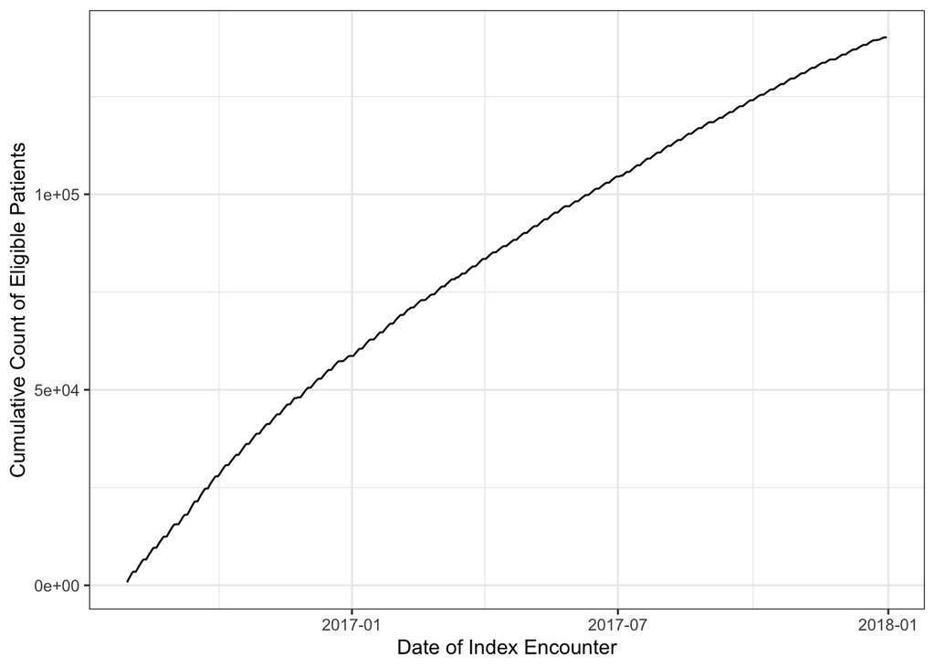

```r
pat_unique %>%
  group_by(index_enc_date) %>%
  summarise(count=n(), .groups='drop') %>%
  mutate(cumulative_count = cumsum(count)) %>%
  ggplot(data=., aes(x=index_enc_date, y=cumulative_count)) +
  geom_line() +
  ylab('Cumulative Count of Eligible Patients') +
  xlab('Date of Index Encounter') +
  theme_bw()
```

### Provider specialty at index encounter

```r
## need to separate provider specialties
general_care <- c('ACUTE CARE NURSE PRACTITIONER'
                  ,'ADULT HEALTH NURSE PRACTITIONER'
                  ,'GENERAL PRACTICE'
                  ,'MEDICINE, ADULT'
                  ,'MEDICINE, FAMILY MEDICINE'
                  ,'MEDICINE, INTERNAL MEDICINE'
                  ,'NURSE PRACTITIONER'
                  , "FAMILY NURSE PRACTITIONER"
                  , "PEDIATRIC NURSE PRACTITIONER"
                  , "PEDIATRICS, ADOLESCENT MEDICINE"
                  , "PEDIATRICS, GENERAL"
                  , "PHYSICIAN ASSISTANT"
                  , "PHYSICIAN ASSISTANT, MEDICAL"
                  , "REGISTERED NURSE")
obgyn_care <- c('OBSTETRICS & GYNECOLOGY'
                ,'OBSTETRICS & GYNECOLOGY NURSE PRACTITIONER'
                ,'OBSTETRICS GYNECOLOGY, GENERAL'
                , "WOMEN'S HEALTH NURSE PRACTITIONER")
gyn_care <- c('GYNECOLOGY, GENERAL'
              ,'GYNECOLOGY, REPRODUCTIVE ENDOCRINOLOGY'
              ,'GYNECOLOGY, URO-GYNECOLOGY'
              ,'UROLOGY, URO-GYNECOLOGY'
              , "GYNECOLOGY, GYNECOLOGIC ONCOLOGY")
endocrine_care <- c('MEDICINE, ENDOCRINOLOGY','MEDICINE, ENDOCRINOLOGY, DIABETES, OBESITY, METABOLISM'
                    ,  "PEDIATRIC ENDOCRINOLOGY")
ob_care <- c('OBSTETRICS, GENERAL','OBSTETRICS, MATERNAL FETAL MEDICINE')
ed_care <- c("EMERGENCY MEDICINE, ADULT"
                , "EMERGENCY MEDICINE, GENERAL"
                , "EMERGENCY MEDICINE, PEDIATRICS"
                , "URGENT CARE")
all_relevant_providers <- c(general_care, gyn_care, ob_care, obgyn_care, endocrine_care, ed_care)
```

```r
pat_unique %>%
  mutate(`OBGYN general` = case_when(grepl(paste(obgyn_care,collapse="|"),
                                      toupper(all_provider_specialty))~TRUE,TRUE~FALSE),
         Gynecology = case_when(grepl(paste(gyn_care,collapse="|"),
                                      toupper(all_provider_specialty))~TRUE,TRUE~FALSE),
         Obstetrics = case_when(grepl(paste(ob_care,collapse="|"),
                                     toupper(all_provider_specialty))~TRUE,TRUE~FALSE),
         `General Care` = case_when(grepl(paste(general_care,collapse="|"),
                                        toupper(all_provider_specialty))~TRUE,TRUE~FALSE),
         Endocrinology = case_when(grepl(paste(endocrine_care,collapse="|"),
                                         toupper(all_provider_specialty))~TRUE,TRUE~FALSE),
         `Emergency Care` = case_when(grepl(paste(ed_care,collapse="|"),
                                         toupper(all_provider_specialty))~TRUE,TRUE~FALSE))%>%
  CreateCatTable(data=., vars=c('OBGYN general', 'Gynecology', 'Obstetrics',
                                'General Care', 'Endocrinology', 'Emergency Care'))
```

```
##
##                             Overall
##   n                         140116
##   OBGYN general = TRUE (%)  26342 (18.8)
##   Gynecology = TRUE (%)     39165 (28.0)
##   Obstetrics = TRUE (%)     10797 ( 7.7)
##   General Care = TRUE (%)   81267 (58.0)
##   Endocrinology = TRUE (%)   5457 ( 3.9)
##   Emergency Care = TRUE (%)  3427 ( 2.4)
```

Since patients might attend more than one encounter on their index date, the percent adds up to more than 100%. Generally the majority of patients attended some general care provider at their index encounter.

### Age distribution

```r
CreateTableOne(data=pat_unique, var='age_20160801', includeNA=TRUE)
```

```
##
##                            Overall
##   n                        140116
##   age_20160801 (mean (SD))  33.43 (8.97)
```

A number of patients (n = 459) went through menopause before the beginning of cohort entry and should be excluded.

### Alive

```r
pat_unique$death_date <- ifelse(pat_unique$death_date=='NULL', NA, pat_unique$death_date)
pat_unique$death_date <- parse_date_time(pat_unique$death_date, orders = 'Ymd HMS', quiet=TRUE)
```

```r
summary(pat_unique$death_date)
pat_unique %>% filter(index_enc_date >= death_date)
# double check that everyone indicated as dead has a death date
length(which(pat_cohort$pat_living_stat_c == 2 & pat_cohort == 'NULL')) #TRUE
```

As it should be, there are 0 patients who have died prior to their index encounter date.

### Disease-free at baseline

```r
# Combine tables that need combining
uf_endo_filled <- uf_endo %>%
  mutate(dx_date = as.Date(dx_date, "%Y-%m-%d")) %>%
  ## remove those missing a dx date
  filter(!is.na(dx_date) & icd10 != 'N80.03') %>%
  ## add in filled dx_date where missing
  bind_rows(uf_endo_filled_dates %>%
              filter(icd10 != 'N80.03') %>%
              mutate(dx_date_filled = as.Date(dx_date_filled, "%Y-%m-%d"),
                     dx_date = as.Date(dx_date, "%Y-%m-%d"),
                     dx_date = case_when(is.na(dx_date)~dx_date_filled, TRUE~dx_date))) %>%
  ## add in index encounter date
  left_join(pat_unique %>% select(pat_id, index_enc_date), by = 'pat_id')
```

```r
uf_endo_before_baseline <- uf_endo_filled %>%
  group_by(pat_id) %>%
  filter(dx_date == pmin(dx_date, na.rm=TRUE)) %>%
  ungroup() %>%
  filter(dx_date <= '2016-08-01' | dx_date <= index_enc_date)

length(which(uf_endo_filled$dx_date <= uf_endo_filled$index_enc_date))
```

```
## [1] 13593
```

There are 5007 patients who have a UF or Endo diagnosis prior to their index encounter or before entry into cohort that were missed in initial cohort screening. These should be excluded further from inclusion.

1266 of them are referral diagnoses. 4666 of them are diagnoses received on the same date as their index encounter.

```r
missing_dx_encounters <- uf_endo_before_baseline %>%
  filter(dx_type != 'Referral Diagnosis' & dx_date != index_enc_date)
## there are some encounters not being counted as index encounters where patients are diagnosed with UF/Endo
## these are mostly none relevant care diagnoses (likely not encounter diagnoses but medical histories)
## see enc_w_uf_endo_dx.sql for more details
```

### Regular relevant care in two years since baseline

```r
# take all encounters after a patients index encounter and with relevant care
all_enc_ip_op <- rbind(enc_obgyn, enc_generalMD, enc_other)

ed_FU_all <- enc_ed %>%
  left_join(pat_unique %>% select(pat_id, index_enc_date), by='pat_id') %>%
  mutate(enc_date = as.Date(enc_date)) %>%
  filter(enc_date > index_enc_date) %>%
  filter(toupper(longest_prov_specialty) %in% all_relevant_providers) %>%
  select(pat_id, pat_enc_csn_id, enc_type, enc_date, longest_prov_specialty, index_enc_date) %>%
  rename(provider_specialty = longest_prov_specialty)

ip_op_FU_all <- all_enc_ip_op %>%
  left_join(pat_unique %>% select(pat_id, index_enc_date), by='pat_id') %>%
  mutate(enc_date = as.Date(enc_date)) %>%
  filter(enc_date > index_enc_date) %>%
  filter(toupper(provider_specialty) %in% all_relevant_providers) %>%
  select(pat_id, pat_enc_csn_id, enc_type, enc_date, provider_specialty, index_enc_date)
```

```r
# look at average length to next visit for all patients
time_to_first_FU <- bind_rows(ed_FU_all, ip_op_FU_all) %>%
  mutate(FU_margin = difftime(enc_date, index_enc_date, units='days')) %>%
  group_by(pat_id) %>%
  filter(FU_margin == min(FU_margin)) %>%
  ungroup() %>%
  distinct(pat_id, FU_margin, provider_specialty)
```

Regularity of relevant care among eligible patients:

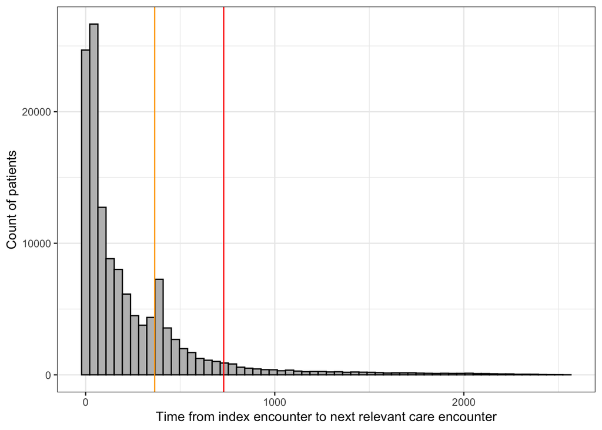

```r
# plot the distribution
time_to_first_FU %>%
  ggplot(aes(x=as.numeric(FU_margin))) +
  geom_histogram(bins=60, fill='gray', color='black') +
  geom_vline(xintercept=365, color='orange') +
  geom_vline(xintercept=730, color='red') +
  xlab('Time from index encounter to next relevant care encounter') +
  ylab('Count of patients') +
  theme_bw()
```

The orange line indicates one year from index encounter to next relevant care encounter. The red line indicates two years.

The final number of patients who have relevant care in the two years following their index encounter is n=120703 (93% of eligible patients). These are the patients who can truly be followed for potential diagnosis since they maintain care in the first two years of follow-up. Other patients we consider not regular and therefore not at risk of diagnosis.

Type of care in first follow-up encounter:

```r
time_to_first_FU %>%
  mutate(`OBGYN general` = case_when(grepl(paste(obgyn_care,collapse="|"),
                                      toupper(provider_specialty))~TRUE,TRUE~FALSE),
         Gynecology = case_when(grepl(paste(gyn_care,collapse="|"),
                                      toupper(provider_specialty))~TRUE,TRUE~FALSE),
         Obstetrics = case_when(grepl(paste(ob_care,collapse="|"),
                                     toupper(provider_specialty))~TRUE,TRUE~FALSE),
         `General Care` = case_when(grepl(paste(general_care,collapse="|"),
                                        toupper(provider_specialty))~TRUE,TRUE~FALSE),
         Endocrinology = case_when(grepl(paste(endocrine_care,collapse="|"),
                                         toupper(provider_specialty))~TRUE,TRUE~FALSE),
         `Emergency Care` = case_when(grepl(paste(ed_care,collapse="|"),
                                         toupper(provider_specialty))~TRUE,TRUE~FALSE))%>%
  CreateCatTable(data=., vars=c('OBGYN general', 'Gynecology', 'Obstetrics',
                                'General Care', 'Endocrinology', 'Emergency Care'))
```

```
##
##                             Overall
##   n                         129473
##   OBGYN general = TRUE (%)  23688 (18.3)
##   Gynecology = TRUE (%)     34142 (26.4)
##   Obstetrics = TRUE (%)      8997 ( 6.9)
##   General Care = TRUE (%)   66339 (51.2)
##   Endocrinology = TRUE (%)   4458 ( 3.4)
##   Emergency Care = TRUE (%)  7992 ( 6.2)
```

```r
pat_unique_final <- pat_unique %>%
  filter(!pat_id %in% uf_endo_before_baseline$pat_id) %>%
  filter(!pat_id %in% unique(menopause$pat_id[which(as.Date(menopause$dx_date)<= '2016-08-01')])) %>%
  filter(pat_id %in% time_to_first_FU$pat_id[which(time_to_first_FU$FU_margin <= 730)])
```

## 1.2. Loss to follow-up

```r
# identify any gaps in care for more than two years
all_FU_w_gaps <- bind_rows(ed_FU_all, ip_op_FU_all) %>%
  filter(pat_id %in% pat_unique_final$pat_id) %>%
  ## collapse across encounters on the same day
  distinct(pat_id, pat_enc_csn_id, enc_date, index_enc_date) %>%
  arrange(pat_id, enc_date) %>%
  group_by(pat_id) %>%
  mutate(next_enc_date = lead(enc_date),
         wks_to_next_enc = as.numeric(next_enc_date-enc_date)/7) %>%
  mutate(wks_to_next_enc = case_when(is.na(wks_to_next_enc)~as.numeric(as.Date('2023-08-01')-enc_date)/7,
                                     TRUE~wks_to_next_enc)) %>%
  # define their most recent encounter
  mutate(most_recent_enc_date = max(enc_date)) %>%
  ungroup()
```

```r
# for each patient take their max gap and their time from the end of follow-up
ltfu_unique <- all_FU_w_gaps %>%
  ## select all gaps where a patient disengages for two years or more
  filter(wks_to_next_enc >= 104) %>%
  group_by(pat_id) %>%
  ## find the earliest date when they do this
  filter(enc_date == min(enc_date)) %>%
  ## if this date is not the same as their last
  ungroup() %>%
  mutate(ltfu_status = case_when(enc_date == most_recent_enc_date ~ 'complete',
                                 enc_date != most_recent_enc_date ~ 'partial'),
         ltfu_date = enc_date,
         ltfu_reengage_date = next_enc_date)
```

The number of patients who completely disengage at some point during follow-up (disengage for two years and stay disengaged until the end of follow-up) is n=46933.

The number of patients who partially disengage at some point during follow-up (disengage for two years or more but re-engaged in relevant care before the end of follow-up) is n=17788.

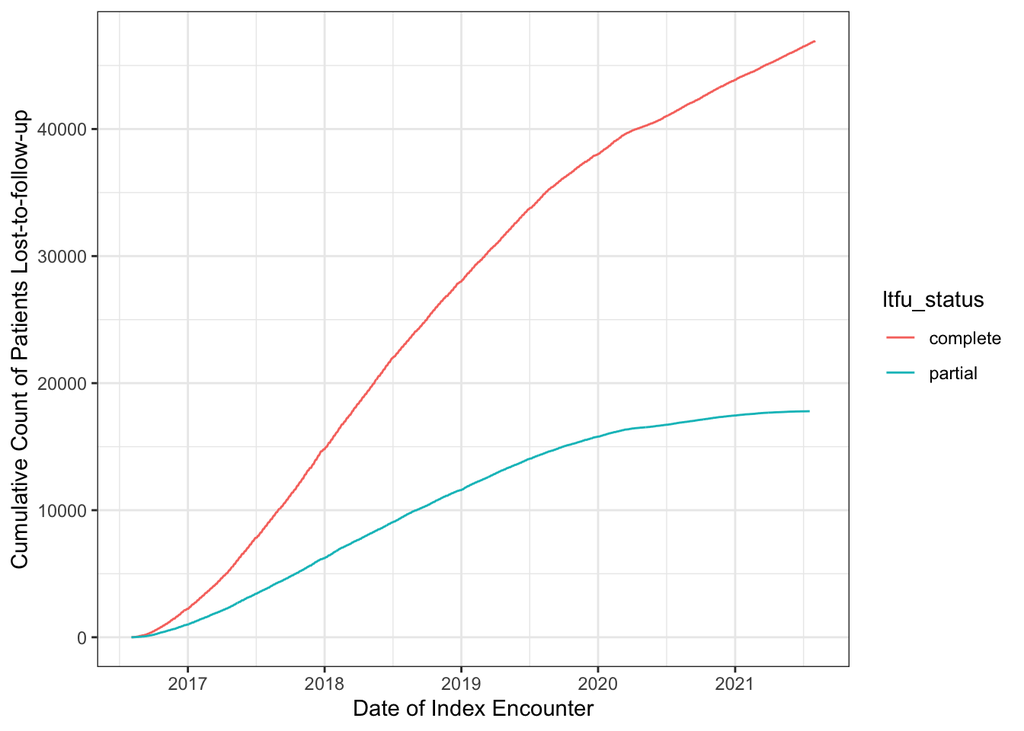

```r
ltfu_unique %>%
  group_by(ltfu_date, ltfu_status) %>%
  summarise(count=n(), .groups='drop') %>%
  group_by(ltfu_status) %>%
  mutate(cumulative_count = cumsum(count)) %>%
  ungroup() %>%
  ggplot(data=., aes(x=ltfu_date, y=cumulative_count, color=ltfu_status)) +
  geom_line() +
  ylab('Cumulative Count of Patients Lost-to-follow-up') +
  xlab('Date of Index Encounter') +
  theme_bw()
```

NOTE: this includes all patients regardless of other censoring and case diagnosis. A more accurate summary of LTFU will be at the end of the document.

## 1.3. Censoring not due to diagnosis of UF or Endo

### Death

There are 135 patient who died during the follow-up period.

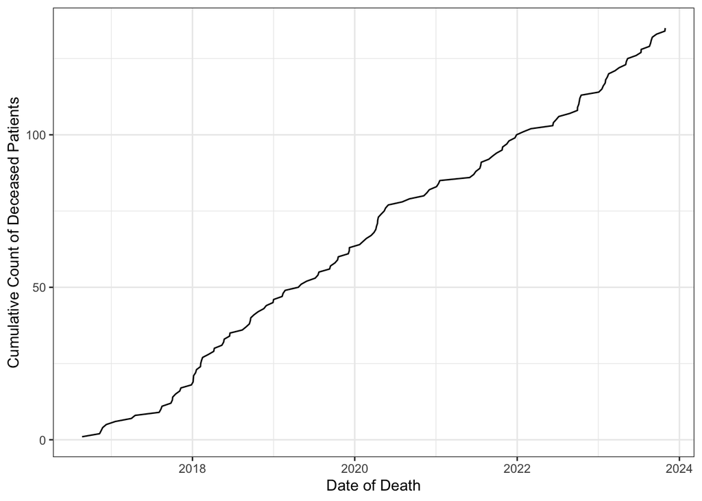

```r
pat_unique_final %>%
  filter(!is.na(death_date)) %>%
  group_by(death_date) %>%
  summarise(count=n(), .groups='drop') %>%
  mutate(cumulative_count = cumsum(count)) %>%
  ggplot(data=., aes(x=death_date, y=cumulative_count)) +
  geom_line() +
  ylab('Cumulative Count of Deceased Patients') +
  xlab('Date of Death') +
  theme_bw()
```

### Hysterectomy or bilateral oophorectomy

```r
# do I need to use codes?
cpt_codes <- c('1962', '38589', '58150', '58180', '58210', '58260',
               '58541', '58542', '58544', '58550', '58553', '58570',
               '58572', '58573', 'SHX1221', 'SHX1223', 'SHX1926', 'SHX1934',
               'SHX209', 'SHX210', 'SHX21050', 'SHX2362', 'SHX2548', 'SHX81',
               'SHX82', 'SUR292', 'SUR658', 'SUR661', 'SUR797', 'SUR800')

length(which(surgery$procedure_code %in% cpt_codes)) ## none of these show up table so ignore
```

The surgery table includes completed and scheduled surgeries so I need to remove those prior to cohort entry and after the last date of follow-up.

```r
## only focus on surgeries during follow-up
surgery_FU <- surgery %>%
  mutate(surgery_date = as.Date(surgery_date)) %>%
  filter(surgery_date > '2016-08-01' & surgery_date <= '2023-10-01')
```

```r
# mark procedure names from above
censor_surg <- surgery_FU %>%
  mutate(hysterectomy = case_when(grepl('HYSTERECTOMY', procedure_name)~TRUE),
         bilateral_oophorectomy = case_when(grepl('OOPHORECTOMY', procedure_name) &
                                    grepl('BILATERAL', procedure_name)~TRUE,
                                  grepl('OOPHORECTOMY', procedure_name) &
                                    grepl('Bilateral', laterality)~TRUE)) %>%
  filter(hysterectomy | bilateral_oophorectomy)
```

```r
# look at patient with multiple observations
censor_surg %>%
  group_by(pat_id) %>%
  filter(n()>1) %>%
  arrange(pat_id, surgery_date) %>%
  View()
```

```r
# turn into observations per patient id
censor_surg_unique <- censor_surg %>%
  filter(pat_id %in% pat_unique_final$pat_id) %>%
  group_by(pat_id, surgery_date) %>%
  mutate(hysterectomy = case_when(sum(hysterectomy, na.rm=T)>=1~TRUE),
         bilateral_oophorectomy = case_when(sum(bilateral_oophorectomy, na.rm=T)>=1~TRUE)) %>%
  ungroup() %>%
  select(pat_id, surgery_date, hysterectomy, bilateral_oophorectomy) %>%
  distinct() %>%
  group_by(pat_id) %>%
  filter(surgery_date==min(surgery_date)) %>%
  ungroup() %>%
  rename(censor_surg_date = surgery_date)
```

There are 1029 patients who receive a hysterectomy or bilateral oophorectomy at some point during follow-up. 689 patients received a hysterectomy only, 110 patients received a bilateral oophorectomy only, and 230 patients received both.

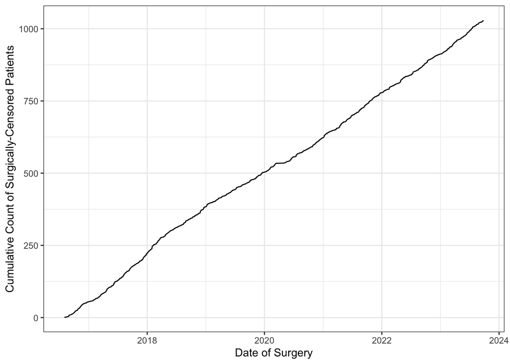

```r
censor_surg_unique %>%
  group_by(censor_surg_date) %>%
  summarise(count=n_distinct(pat_id), .groups='drop') %>%
  mutate(cumulative_count = cumsum(count)) %>%
  ggplot(data=., aes(x=censor_surg_date, y=cumulative_count, label=cumulative_count)) +
  geom_line() +
  ylab('Cumulative Count of Surgically-Censored Patients') +
  xlab('Date of Surgery') +
  theme_bw()
```

**NEXT STEP**: Some of these are very close to entry into cohort – if so they will be censored very early, should they be excluded similar to not getting relevant care in the year following entry into cohort? I guess if they did not receive a diagnosis during this time prior to surgery then they just received the procedure for some other reason which is fine.

### Menopause (aging out)

```r
menopause_unique <- menopause %>%
  group_by(pat_id) %>%
  filter(dx_date == min(dx_date)) %>%
  arrange(pat_id, dx_date) %>%
  mutate(menopause_date = as.Date(dx_date, '%Y-%m-%d')) %>%
  distinct(pat_id, menopause_date)
```

The total number of patients who have any menopause diagnosis (and therefore would be censored at this point) is n=4702.

```r
age_out <- pat_unique_final %>%
  select(pat_id, age_20160801) %>%
  mutate(ageout_date = as.Date('2016-08-01') %m+% years(55-age_20160801)) %>%
  mutate(ageout_date = case_when(ageout_date > '2023-10-01'~NA,
                                 TRUE~ageout_date))
```

The total number of patients who age out of the cohort during follow-up (55 or older) is n=7268.

## Join together all dates of potential censoring/LTFU

```r
pat_unique_final <- pat_unique_final %>%
  left_join(ltfu_unique %>% select(pat_id, contains('ltfu')), by='pat_id') %>%
  left_join(censor_surg_unique %>% select(pat_id, censor_surg_date), by='pat_id') %>%
  left_join(menopause_unique, by='pat_id') %>%
  left_join(age_out %>% select(pat_id, ageout_date), by='pat_id')
```

```r
# create final censoring variables
pat_unique_final <- pat_unique_final %>%
  mutate(final_censor_date = pmin(as.Date(death_date), ltfu_date, censor_surg_date, menopause_date, ageout_date, na.rm = TRUE)) %>%
  mutate(final_censor_type = case_when(final_censor_date == as.Date(death_date)~'Death',
                                       final_censor_date == censor_surg_date~'Surgery',
                                       final_censor_date == menopause_date~'Menopause',
                                       final_censor_date == ageout_date~'Aged out',
                                       final_censor_date == ltfu_date~'LTFU',
                                       TRUE~NA))
```

Distribution of first censoring event in entire cohort: (excluding due to disease diagnosis)

```r
pat_unique_final %>%
  filter(!is.na(final_censor_type)) %>%
  CreateTableOne(data=., vars='final_censor_type')
```

```
##
##                         Overall
##   n                     70589
##   final_censor_type (%)
##      Aged out            2957 ( 4.2)
##      Death                 28 ( 0.0)
##      LTFU               63848 (90.5)
##      Menopause           2882 ( 4.1)
##      Surgery              874 ( 1.2)
```

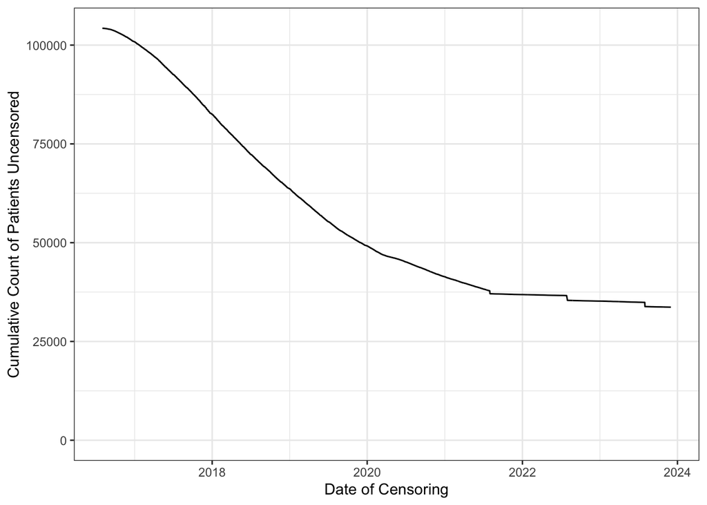

```r
n_total <- length(unique(pat_unique_final$pat_id))

pat_unique_final %>%
  group_by(final_censor_date) %>%
  summarise(count=n(), .groups='drop') %>%
  mutate(cumulative_count = n_total - cumsum(count)) %>%
  ggplot(data=., aes(x=final_censor_date, y=cumulative_count)) +
  geom_line() +
  ylab('Cumulative Count of Patients Uncensored') +
  xlab('Date of Censoring') +
  theme_bw()
```

```r
## write out file with date and reason for LTFU or censoring during follow-up for all patients
write.csv(pat_unique_final, 'Data/Derived/pat_cohort_w_censoring.csv')
## some may be retrospectively overwritten if they are diagnosed with UF or Endo before that point
```